# Employee Attrition Prediction

```python
stayed_df.describe()
```

|  | Age | Attrition | DailyRate | DistanceFromHome | Education | EnvironmentSatisfaction | HourlyRate | JobInvolvement | JobLevel | JobSatisfaction | ... | PerformanceRating | RelationshipSatisfaction | StockOptionLevel | TotalWorkingYears | TrainingTimesLastYear | WorkLifeBalance | YearsAtCompany | YearsInCurrentRole | YearsSinceLastPromotion | YearsWithCurrManager |
| --- | --- | --- | --- | --- | --- | --- | --- | --- | --- | --- | --- | --- | --- | --- | --- | --- | --- | --- | --- | --- | --- |
| count | 1233.000000 | 1233.0 | 1233.000000 | 1233.000000 | 1233.000000 | 1233.000000 | 1233.000000 | 1233.000000 | 1233.000000 | 1233.000000 | ... | 1233.000000 | 1233.000000 | 1233.000000 | 1233.000000 | 1233.000000 | 1233.000000 | 1233.000000 | 1233.000000 | 1233.000000 | 1233.000000 |
| mean | 37.561233 | 0.0 | 812.504461 | 8.915653 | 2.927007 | 2.771290 | 65.952149 | 2.770479 | 2.145985 | 2.778589 | ... | 3.153285 | 2.733982 | 0.845093 | 11.862936 | 2.832928 | 2.781022 | 7.369019 | 4.484185 | 2.234388 | 4.367397 |
| std | 8.888360 | 0.0 | 403.208379 | 8.012633 | 1.027002 | 1.071132 | 20.380754 | 0.692050 | 1.117933 | 1.093277 | ... | 0.360408 | 1.071603 | 0.841985 | 7.760719 | 1.293585 | 0.681907 | 6.096298 | 3.649402 | 3.234762 | 3.594116 |
| min | 18.000000 | 0.0 | 102.000000 | 1.000000 | 1.000000 | 1.000000 | 30.000000 | 1.000000 | 1.000000 | 1.000000 | ... | 3.000000 | 1.000000 | 0.000000 | 0.000000 | 0.000000 | 1.000000 | 0.000000 | 0.000000 | 0.000000 | 0.000000 |
| 25% | 31.000000 | 0.0 | 477.000000 | 2.000000 | 2.000000 | 2.000000 | 48.000000 | 2.000000 | 1.000000 | 2.000000 | ... | 3.000000 | 2.000000 | 0.000000 | 6.000000 | 2.000000 | 2.000000 | 3.000000 | 2.000000 | 0.000000 | 2.000000 |
| 50% | 36.000000 | 0.0 | 817.000000 | 7.000000 | 3.000000 | 3.000000 | 66.000000 | 3.000000 | 2.000000 | 3.000000 | ... | 3.000000 | 3.000000 | 1.000000 | 10.000000 | 3.000000 | 3.000000 | 6.000000 | 3.000000 | 1.000000 | 3.000000 |
| 75% | 43.000000 | 0.0 | 1176.000000 | 13.000000 | 4.000000 | 4.000000 | 83.000000 | 3.000000 | 3.000000 | 4.000000 | ... | 3.000000 | 4.000000 | 1.000000 | 16.000000 | 3.000000 | 3.000000 | 10.000000 | 7.000000 | 3.000000 | 7.000000 |
| max | 60.000000 | 0.0 | 1499.000000 | 29.000000 | 5.000000 | 4.000000 | 100.000000 | 4.000000 | 5.000000 | 4.000000 | ... | 4.000000 | 4.000000 | 3.000000 | 38.000000 | 6.000000 | 4.000000 | 37.000000 | 18.000000 | 15.000000 | 17.000000 |

8 rows × 25 columns

Visualize the correlation matrix and explore what insights can be derived from the data

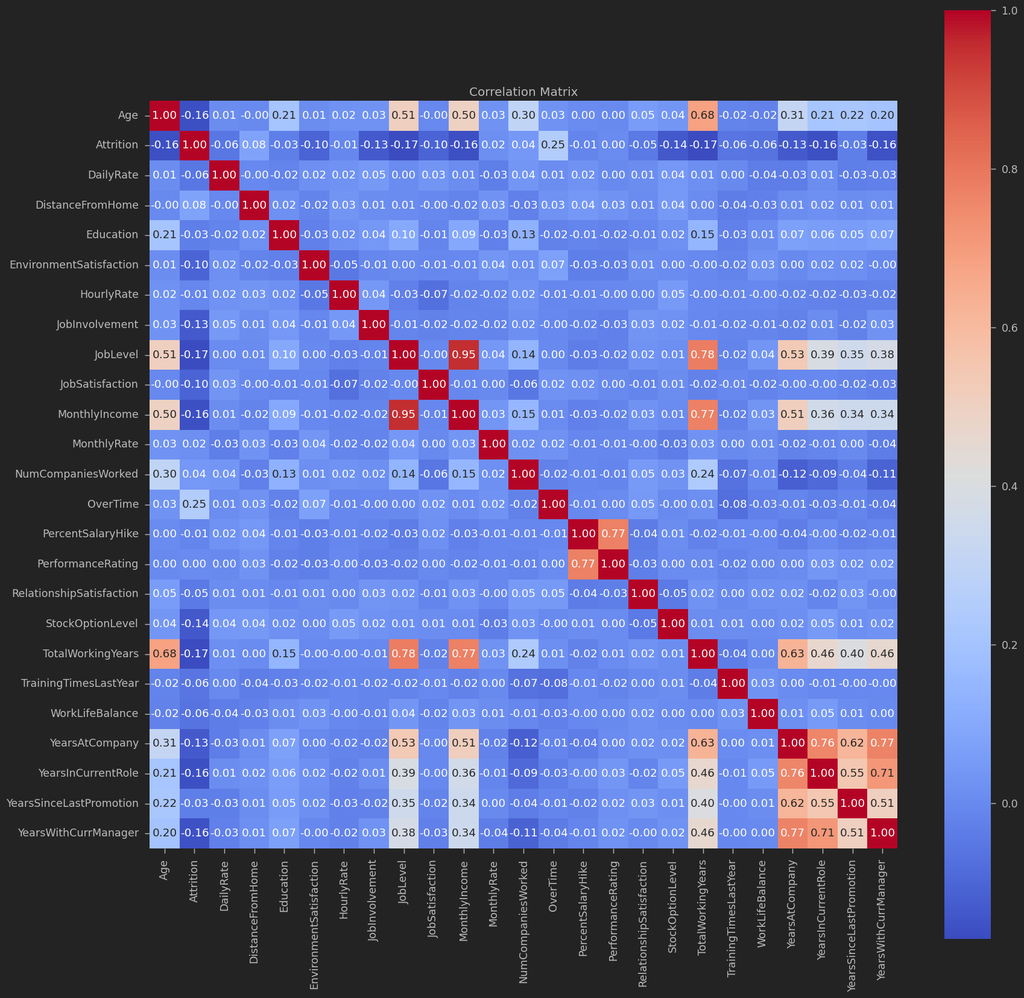

```python
# Drop non-numeric columns
numeric_df = employee_df.select_dtypes(include='number')

# Compute correlation matrix
correlations = numeric_df.corr()

# Plot correlation matrix
plt.figure(figsize=(20, 20))
sns.heatmap(correlations, annot=True, cmap='coolwarm', fmt=".2f", square=True)
plt.title('Correlation Matrix')
plt.show()
```

The correlation between JobLevel and Monthly Income, as well as TotalWorkingYears, is notable. It's logical that individuals who have been with the company for an extended period and have attained higher job levels would likely have higher incomes. This correlation underscores the relationship between tenure, promotion, and earning potential within the organization.

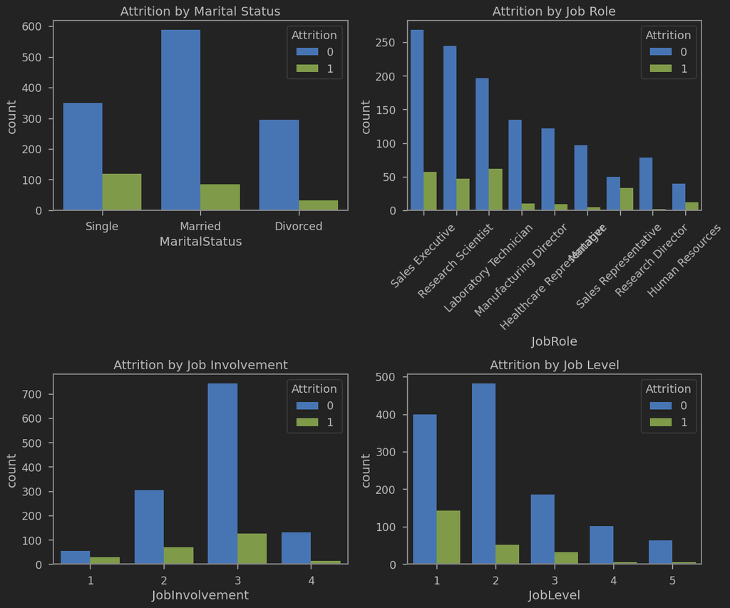

```python
# Set the figure size
plt.figure(figsize=[12, 10])

# Subplot 1: Marital Status vs. Attrition
plt.subplot(221)
sns.countplot(x='MaritalStatus', hue='Attrition', data=employee_df)
plt.title('Attrition by Marital Status')

# Subplot 2: Job Role vs. Attrition
plt.subplot(222)
sns.countplot(x='JobRole', hue='Attrition', data=employee_df)
plt.title('Attrition by Job Role')
plt.xticks(rotation=45)  # Rotate x-axis labels for better readability

# Subplot 3: Job Involvement vs. Attrition
plt.subplot(223)
sns.countplot(x='JobInvolvement', hue='Attrition', data=employee_df)
plt.title('Attrition by Job Involvement')

# Subplot 4: Job Level vs. Attrition
plt.subplot(224)
sns.countplot(x='JobLevel', hue='Attrition', data=employee_df)
plt.title('Attrition by Job Level')

# Adjust layout to prevent overlapping
plt.tight_layout()

# Show the plot
plt.show()
```

Single employees exhibit a higher likelihood of departure compared to those who are married or divorced. Sales representatives show a higher tendency to leave their positions compared to individuals in other job roles. Employees with lower levels of involvement demonstrate a higher propensity to leave the company. Additionally, individuals with lower levels of job experience, indicated by their job level, tend to depart from the company more frequently.

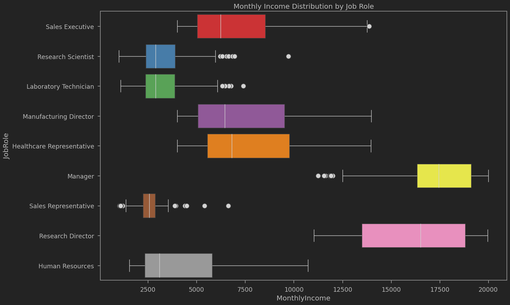

```python
# Examine the relationship between monthly income and job roles.
plt.figure(figsize=(15, 10))

flierprops = dict(marker='o', markerfacecolor='lightgray', markersize=10, linestyle='none')

sns.boxplot(x = 'MonthlyIncome', y = 'JobRole', data = employee_df, palette='Set1', flierprops=flierprops)

for line in plt.gca().get_lines():
    line.set_color('lightgray')


plt.title('Monthly Income Distribution by Job Role')
```

```python
# KDE (Kernel Density Estimate) is used to visualize the Probability Density of a continuous variable, describing the probability density across various values within that variable.

plt.figure(figsize=(12,7))

sns.kdeplot(left_df['DistanceFromHome'], label = 'Employees who left', shade = True, color = 'salmon', linewidth=2, edgecolor='salmon')
sns.kdeplot(stayed_df['DistanceFromHome'], label = 'Employees who stayed', shade = True, color = 'lightblue', linewidth=2, edgecolor='lightblue')

plt.title('Distribution of Distance from Home for Employees Who Left vs. Stayed')
plt.legend()
```

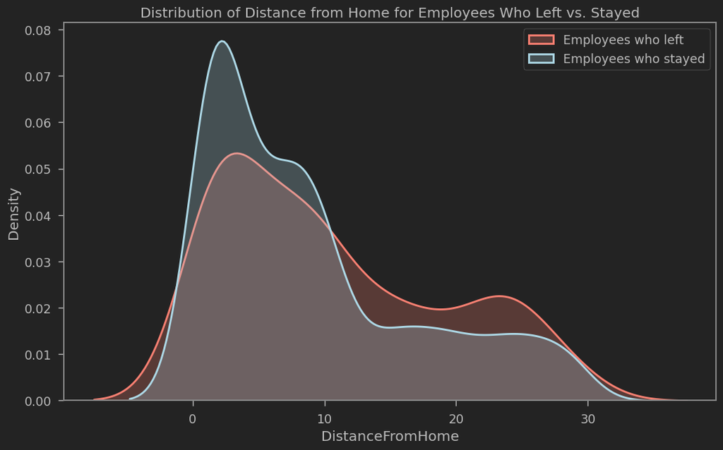

```python
plt.figure(figsize=(12,7))

sns.kdeplot(left_df['YearsWithCurrManager'], label = 'Employees who left', shade = True, color = 'Teal', linewidth=2, edgecolor='Teal')
sns.kdeplot(stayed_df['YearsWithCurrManager'], label = 'Employees who Stayed', shade = True, color = 'Gold', linewidth=2, edgecolor='Gold')

plt.title('Distribution of Years With Current Manager for Employees Who Left vs. Stayed')
plt.legend()
```

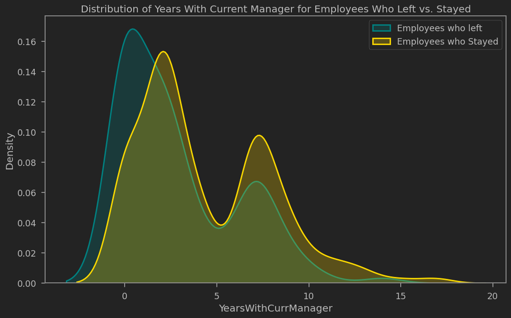

Visualize the Kernel Density Estimate (KDE) for the total years of employment and contrast it between employees who left and those who remained with the company.

```python
plt.figure(figsize=(12,7))

sns.kdeplot(left_df['TotalWorkingYears'], label = 'Employees who left', shade = True,  color = 'Pink', linewidth=2, edgecolor='Pink')
sns.kdeplot(stayed_df['TotalWorkingYears'], label = 'Employees who Stayed', shade = True, color = 'Turquoise', linewidth=2, edgecolor='Turquoise')

plt.xlabel('Distribution of Total Working Years Between Employees Who Left And Those Who Stayed')
plt.legend()
```

[figure not shown]

# CREATE TESTING, TRAINING DATASET & PERFORM DATA CLEANING

```python
employee_df.head(3)
```

|  | Age | Attrition | BusinessTravel | DailyRate | Department | DistanceFromHome | Education | EducationField | EnvironmentSatisfaction | Gender | ... | PerformanceRating | RelationshipSatisfaction | StockOptionLevel | TotalWorkingYears | TrainingTimesLastYear | WorkLifeBalance | YearsAtCompany | YearsInCurrentRole | YearsSinceLastPromotion | YearsWithCurrManager |
| --- | --- | --- | --- | --- | --- | --- | --- | --- | --- | --- | --- | --- | --- | --- | --- | --- | --- | --- | --- | --- | --- |
| 0 | 41 | 1 | Travel_Rarely | 1102 | Sales | 1 | 2 | Life Sciences | 2 | Female | ... | 3 | 1 | 0 | 8 | 0 | 1 | 6 | 4 | 0 | 5 |
| 1 | 49 | 0 | Travel_Frequently | 279 | Research & Development | 8 | 1 | Life Sciences | 3 | Male | ... | 4 | 4 | 1 | 10 | 3 | 3 | 10 | 7 | 1 | 7 |
| 2 | 37 | 1 | Travel_Rarely | 1373 | Research & Development | 2 | 2 | Other | 4 | Male | ... | 3 | 2 | 0 | 7 | 3 | 3 | 0 | 0 | 0 | 0 |

3 rows × 31 columns

```python
import pandas as pd
from sklearn.preprocessing import OneHotEncoder, MinMaxScaler

# Extract categorical features
X_cat = employee_df[['BusinessTravel', 'Department', 'EducationField', 'Gender', 'JobRole', 'MaritalStatus']]

# Extract numerical features
# Dropped the target 'Atrittion'
X_numerical = employee_df[['Age', 'DailyRate', 'DistanceFromHome', 'Education', 'EnvironmentSatisfaction',
                            'HourlyRate', 'JobInvolvement', 'JobLevel', 'JobSatisfaction', 'MonthlyIncome',
                            'MonthlyRate', 'NumCompaniesWorked', 'OverTime', 'PercentSalaryHike',
                            'PerformanceRating', 'RelationshipSatisfaction', 'StockOptionLevel',
                            'TotalWorkingYears', 'TrainingTimesLastYear', 'WorkLifeBalance', 'YearsAtCompany',
                            'YearsInCurrentRole', 'YearsSinceLastPromotion', 'YearsWithCurrManager']]

# Initialize OneHotEncoder
onehotencoder = OneHotEncoder()

# Fit and transform the categorical features
X_cat_encoded = onehotencoder.fit_transform(X_cat)

# Convert the encoded features to a DataFrame
X_cat_encoded_df = pd.DataFrame(X_cat_encoded.toarray(), columns=onehotencoder.get_feature_names_out(X_cat.columns))

# Ensure all column names are strings
X_numerical.columns = X_numerical.columns.astype(str)

# Combine encoded categorical features with numerical features
X_all = pd.concat([X_cat_encoded_df, X_numerical], axis=1)

# Apply MinMaxScaler
scaler = MinMaxScaler()
X = scaler.fit_transform(X_all)

# Now, X_scaled contains your scaled features
```

```python
X
```

```
array([[0.        , 0.        , 1.        , ..., 0.22222222, 0.        ,
        0.29411765],
       [0.        , 1.        , 0.        , ..., 0.38888889, 0.06666667,
        0.41176471],
       [0.        , 0.        , 1.        , ..., 0.        , 0.        ,
        0.        ],
       ...,
       [0.        , 0.        , 1.        , ..., 0.11111111, 0.        ,
        0.17647059],
       [0.        , 1.        , 0.        , ..., 0.33333333, 0.        ,
        0.47058824],
       [0.        , 0.        , 1.        , ..., 0.16666667, 0.06666667,
        0.11764706]])
```

```python
y = employee_df['Attrition']
y
```

```
0       1
1       0
2       1
3       0
4       0
       ..
1465    0
1466    0
1467    0
1468    0
1469    0
Name: Attrition, Length: 1470, dtype: int64
```

Examine the shape of the input and the output.

```python
X.shape
```

```
(1470, 50)
```

```python
y.shape
```

```
(1470,)
```

# TRAIN AND EVALUATE A LOGISTIC REGRESSION CLASSIFIER

```python
from sklearn.model_selection import train_test_split
X_train, X_test, y_train, y_test = train_test_split(X, y, test_size = 0.25)
```

```python
X_train.shape
```

```
(1102, 50)
```

```python
X_test.shape
```

```
(368, 50)
```

```python
from sklearn.linear_model import LogisticRegression
from sklearn.metrics import accuracy_score

model = LogisticRegression()
model.fit(X_train, y_train)

y_pred = model.predict(X_test)
```

```python
y_pred
```

```
array([0, 0, 0, 0, 0, 0, 1, 0, 1, 0, 0, 0, 0, 1, 0, 0, 0, 0, 0, 0, 0, 1,
       0, 0, 1, 1, 0, 0, 0, 0, 0, 0, 0, 0, 0, 0, 0, 0, 1, 1, 0, 0, 0, 0,
       1, 0, 0, 0, 0, 0, 0, 0, 0, 0, 0, 0, 1, 0, 0, 0, 0, 0, 1, 0, 0, 0,
       0, 0, 0, 0, 0, 0, 0, 0, 0, 0, 0, 0, 0, 0, 0, 0, 0, 0, 0, 0, 0, 0,
       0, 0, 0, 0, 1, 0, 0, 1, 0, 0, 0, 0, 0, 0, 0, 0, 0, 0, 0, 0, 0, 0,
       0, 0, 0, 0, 0, 0, 0, 0, 0, 0, 0, 0, 1, 0, 0, 0, 0, 1, 0, 0, 0, 0,
       0, 0, 1, 0, 0, 0, 0, 1, 0, 0, 0, 1, 0, 0, 0, 0, 0, 0, 0, 0, 0, 0,
       0, 0, 0, 1, 1, 0, 0, 0, 0, 0, 0, 0, 0, 0, 0, 1, 0, 0, 0, 1, 0, 0,
       0, 0, 0, 0, 0, 0, 0, 1, 0, 0, 0, 0, 0, 1, 0, 0, 0, 0, 0, 0, 1, 0,
       0, 0, 0, 0, 0, 0, 0, 0, 0, 0, 0, 1, 1, 0, 0, 0, 0, 0, 0, 0, 0, 0,
       0, 0, 0, 0, 0, 0, 0, 1, 0, 0, 0, 0, 0, 0, 0, 0, 0, 0, 0, 0, 0, 0,
       0, 1, 0, 0, 0, 0, 0, 0, 0, 0, 0, 0, 0, 0, 0, 0, 0, 0, 0, 0, 0, 0,
       0, 0, 1, 0, 0, 0, 0, 0, 0, 0, 0, 0, 0, 0, 0, 0, 0, 0, 0, 0, 0, 0,
       0, 0, 0, 0, 1, 0, 0, 0, 0, 1, 0, 0, 0, 0, 0, 0, 0, 0, 0, 0, 0, 1,
       0, 0, 0, 0, 1, 0, 0, 0, 0, 0, 0, 0, 0, 0, 0, 0, 0, 0, 0, 0, 0, 0,
       0, 0, 0, 0, 0, 0, 0, 0, 0, 0, 0, 0, 0, 0, 0, 0, 0, 0, 0, 0, 0, 0,
       0, 0, 0, 0, 0, 0, 0, 0, 0, 0, 0, 0, 0, 0, 0, 0])
```

```python
from sklearn.metrics import confusion_matrix, classification_report

print("Accuracy {} %".format( 100 * accuracy_score(y_pred, y_test)))
```

```
Accuracy 87.77173913043478 %
```

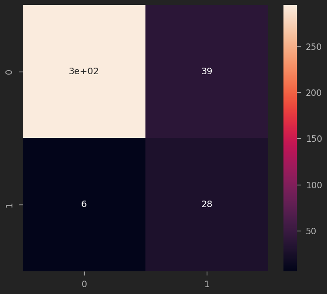

```python
# Testing Set Performance
cm = confusion_matrix(y_pred, y_test)
sns.heatmap(cm, annot=True)
```

```python
print(classification_report(y_test, y_pred))
```

```
              precision    recall  f1-score   support

           0       0.88      0.98      0.93       301
           1       0.82      0.42      0.55        67

    accuracy                           0.88       368
   macro avg       0.85      0.70      0.74       368
weighted avg       0.87      0.88      0.86       368
```

Report Interpretation: Precision: Precision for class 0 (employees not leaving) is 0.88. This means that when the model predicts an employee will not leave, it is correct 88% of the time. Precision for class 1 (employees leaving) is 0.82. This indicates that when the model predicts an employee will leave, it is correct 82% of the time. Recall: Recall for class 0 is 0.98. This suggests that the model correctly identifies 98% of the employees who actually do not leave the company. Recall for class 1 is 0.42. This indicates that the model only captures 42% of the employees who actually leave the company. F1-Score: The F1-score for class 0 is 0.93, which is the harmonic mean of precision and recall for class 0. It balances the trade-off between precision and recall. The F1-score for class 1 is 0.55, which similarly balances the trade-off between precision and recall for class 1. Accuracy: The overall accuracy of the model is 0.88, indicating that it correctly predicts 88% of the cases.

Prediction Interpretation: Based on the provided report, the Logistic Regression model has good precision and recall for predicting class 0 (employees not leaving), but its performance is weaker for predicting class 1 (employees leaving). This suggests that while the model is effective at identifying employees who are likely to stay, it may miss some employees who are likely to leave. Further analysis and potential model improvements could focus on enhancing the model's ability to detect employees who are likely to leave the company. Additionally, exploring features that contribute to employee attrition and refining the model's parameters could help improve its predictive performance.

Train an XGboost algorithm and compare XGBoost model performance to Logistic Regression

```python
from xgboost import XGBClassifier

model = XGBClassifier(use_label_encoder=False)
model.fit(X_train, y_train)
y_pred = model.predict(X_test)
```

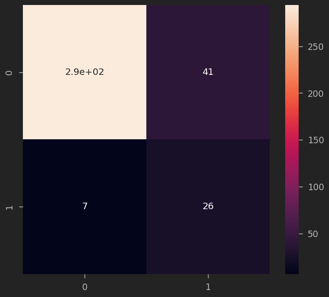

```python
cm = confusion_matrix(y_pred, y_test)
sns.heatmap(cm, annot=True)
```

```python
print(classification_report(y_test, y_pred))
```

```
              precision    recall  f1-score   support

           0       0.88      0.98      0.92       301
           1       0.79      0.39      0.52        67

    accuracy                           0.87       368
   macro avg       0.83      0.68      0.72       368
weighted avg       0.86      0.87      0.85       368
```

Overall, while both models have similar accuracy, the Logistic Regression model generally performs slightly better in terms of precision, recall, and F1-Score for both classes.

```python
from tabulate import tabulate

# Create a list of dictionaries where each dictionary represents the performance metrics for a model
data = [
    {'Metric': 'Accuracy', 'Logistic Regression': 0.88, 'XGBoost': 0.87},
    {'Metric': 'Precision (Class 0)', 'Logistic Regression': 0.88, 'XGBoost': 0.88},
    {'Metric': 'Precision (Class 1)', 'Logistic Regression': 0.82, 'XGBoost': 0.79},
    {'Metric': 'Recall (Class 0)', 'Logistic Regression': 0.98, 'XGBoost': 0.98},
    {'Metric': 'Recall (Class 1)', 'Logistic Regression': 0.42, 'XGBoost': 0.39},
    {'Metric': 'F1-Score (Class 0)', 'Logistic Regression': 0.93, 'XGBoost': 0.92},
    {'Metric': 'F1-Score (Class 1)', 'Logistic Regression': 0.55, 'XGBoost': 0.52},
    {'Metric': 'Macro Avg F1-Score', 'Logistic Regression': 0.74, 'XGBoost': 0.72},
    {'Metric': 'Weighted Avg F1-Score', 'Logistic Regression': 0.86, 'XGBoost': 0.85}
]

# Print the table using the tabulate library with a prettier format
print(tabulate(data, headers='keys', tablefmt='github'))
```

| Metric | Logistic Regression | XGBoost |
| --- | --- | --- |
| Accuracy | 0.88 | 0.87 |
| Precision (Class 0) | 0.88 | 0.88 |
| Precision (Class 1) | 0.82 | 0.79 |
| Recall (Class 0) | 0.98 | 0.98 |
| Recall (Class 1) | 0.42 | 0.39 |
| F1-Score (Class 0) | 0.93 | 0.92 |
| F1-Score (Class 1) | 0.55 | 0.52 |
| Macro Avg F1-Score | 0.74 | 0.72 |
| Weighted Avg F1-Score | 0.86 | 0.85 |

```python
from tabulate import tabulate

# Create a dictionary with model names as keys and their performance metrics as values
data = {
    'Model': ['Logistic Regression', 'XGBoost'],
    'Accuracy': [0.88, 0.87],
    'Precision (Class 0)': [0.88, 0.88],
    'Precision (Class 1)': [0.82, 0.79],
    'Recall (Class 0)': [0.98, 0.98],
    'Recall (Class 1)': [0.42, 0.39],
    'F1-Score (Class 0)': [0.93, 0.92],
    'F1-Score (Class 1)': [0.55, 0.52],
    'Macro Avg F1-Score': [0.74, 0.72],
    'Weighted Avg F1-Score': [0.86, 0.85]
}

# Print the table using the tabulate library with a prettier format
print(tabulate(data, headers='keys', tablefmt='github'))
```

| Model | Accuracy | Precision (Class 0) | Precision (Class 1) | Recall (Class 0) | Recall (Class 1) | F1-Score (Class 0) | F1-Score (Class 1) | Macro Avg F1-Score | Weighted Avg F1-Score |
| --- | --- | --- | --- | --- | --- | --- | --- | --- | --- |
| Logistic Regression | 0.88 | 0.88 | 0.82 | 0.98 | 0.42 | 0.93 | 0.55 | 0.74 | 0.86 |
| XGBoost | 0.87 | 0.88 | 0.79 | 0.98 | 0.39 | 0.92 | 0.52 | 0.72 | 0.85 |